# Bayesian_transmission_model

Daniel Turek

### Hierarchical Model

$$\begin{align}
\text{Priors:} \\
\beta_{1,...,11} &\sim Normal(0, \sigma = 10000) \\
p_{obs.\ source\ plant},\ p_{obs.\ vector} &\sim Uniform(0, 1) \\
p_{trans.\ DSF\ source\ plant},\ p_{trans.\ WT\ source\ plant} &\sim Uniform(0, 1) \\
p_{trans.\ DSF\ vector},\ p_{trans.\ WT\ vector} &\sim Uniform(0, 1) \\
\ \\
\text{Biological model (DSF source plants) (probabilistic transmission):} \\
z^i_{col.\ DSF\ source\ plant} &\sim Bernoulli(p_{col.\ DSF\ source\ plant}) \\
\lambda^i_{DSF\ source\ plant} &= z^i_{col.\ DSF\ source\ plant}
\cdot \exp(\beta_1 + \beta_3 \cdot distance^i) \\
z^i_{col.\ DSF\ vector} &\sim Bernoulli(p_{col.\ DSF\ vector}) \\
\lambda^i_{vector} &= z^i_{col.\ DSF\ vector} \cdot (\beta_5 + \beta_7 \cdot \lambda^i_{source\ plant}) \\
\ \\
\text{Biological model (WT source plants) (probabilistic transmission):} \\
z^i_{col.\ WT\ source\ plant} &\sim Bernoulli(p_{col.\ WT\ source\ plant}) \\
\lambda^i_{WT\ source\ plant} &= z^i_{col.\ WT\ source\ plant}
\cdot \exp(\beta_2 + \beta_4 \cdot distance^i) \\
z^i_{col.\ WT\ vector} &\sim Bernoulli(p_{col.\ WT\ vector}) \\
\lambda^i_{vector} &= z^i_{col.\ DSF\ vector} \cdot (\beta_6 + \beta_8 \cdot \lambda^i_{source\ plant}) \\
\ \\
\text{Source plant observation model:} \\
z^i_{obs.\ source\ plant} &\sim Bernoulli(p_{obs.\ source\ plant}) \\
xf^i_{source\ plant} &\sim Poisson(z^i_{obs.\ source\ plant} \cdot \lambda^i_{source\ plant}) \\
\ \\
\text{Vector observation model:} \\
z^i_{obs.\ vector} &\sim Bernoulli(p_{obs.\ vector}) \\
xf^i_{vector} &\sim Poisson(z^i_{obs.\ vector} \cdot \lambda^i_{vector}) \\
\ \\
\text{Test plant infection model:} \\
\text{logit}(p^i_{transmission}) &= \beta_9 \cdot \text{genotype}_{DSF} +
\beta_{10} \cdot \text{genotype}_{WT} + \beta_{11} \cdot
\lambda^i_{vector} \\
infected^i &\sim Bernoulli(p^i_{transmission}) \\
\end{align}$$

### Data Setup

A few manipulations are done of the input data.

```r
dsf <- readRDS('data/dsf_data_for_nimble.rds')   ## original data file

# Also load plotting functions samplesPlot and chainsPlot
source("R_functions/plotting_functions.R")
```

We specify covariates:

- $genotype_{dsf}=1$ when genotype = DSF, and 0 otherwise
- $genotype_{wt}=1$ when genotype = WT, and 0 otherwise

```r
constants <- list(
    N = dsf$dsfData$N,
    distance = dsf$dsfData$distance,
    ## in original dataset: genotype 1=DSF, 2=WT
    genotype_dsf = ifelse(dsf$dsfData$genotype==1, 1, 0),   ## indicator for DSF
    genotype_wt  = ifelse(dsf$dsfData$genotype==2, 1, 0)    ## indicator for WT
    ## note: test plants are all WT genotype
)
```

The values of the $xf_{vector}$ data are truncated to be integers, for compatibility with the Poisson distribution.

```r
data <- list(
    xf_source_plant = dsf$dsfData$xf_source_plant,
    xf_vector = floor(dsf$dsfData$xf_vector),   ## change to integers
    infected = dsf$dsfData$infected
)
```

We also create three additional vectors of indicies. These contain the indicies of the observed (non-NA) data, for each of $xf_{source\ plant}$, $xf_{vector}$, and $infected$. These will be used in the model to skip creating posterior predictive nodes, which speed up the MCMC and overall mixing considerably.

```r
## indices of observed values for each set of data:
constants$obs_ind_plant <- which(!is.na(data$xf_source_plant))
constants$obs_ind_vector <- which(!is.na(data$xf_vector))
constants$obs_ind_infected <- which(!is.na(data$infected))

## and the counts of each:
constants$N_obs_plant <- length(constants$obs_ind_plant)
constants$N_obs_vector <- length(constants$obs_ind_vector)
constants$N_obs_infected <- length(constants$obs_ind_infected)
```

### Model and MCMC

Use [NIMBLE](https://r-nimble.org/) to build the model and corresponding MCMC algorithm.

```r
library(nimble)

code <- nimbleCode({
    ## priors:
    for(i in 1:11) {
        b[i] ~ dnorm(0, sd=10000)
    }
    p_obs_plant ~ dbeta(1, 1)   ## probability of xf detection in source plant
    p_obs_vector ~ dbeta(1, 1)  ## probability of xf detection in vector
    p_trans_plant_dsf ~ dbeta(1, 1)    ## probabilities of *any* xf transmission to plant measurement site
    p_trans_plant_wt  ~ dbeta(1, 1)    ##
    p_trans_vector_dsf ~ dbeta(1, 1)    ## probabilities of *any* xf transmission to vector
    p_trans_vector_wt  ~ dbeta(1, 1)    ##
    ## biological model:
    for(i in 1:N) {
        ## transmission of xf to plant site:
        z_trans_plant[i] ~ dbern(p_trans_plant_dsf*genotype_dsf[i] + p_trans_plant_wt*genotype_wt[i])
        lambda_plant[i] <- z_trans_plant[i] * exp(b[1]*genotype_dsf[i] + b[2]*genotype_wt[i] + b[3]*distance[i]*genotype_dsf[i] + b[4]*distance[i]*genotype_wt[i])
        ## transmission of xf to vector:
        z_trans_vector[i] ~ dbern(p_trans_vector_dsf*genotype_dsf[i] + p_trans_vector_wt*genotype_wt[i])
        lambda_vector[i] <- z_trans_vector[i] * (b[5]*genotype_dsf[i] + b[6]*genotype_wt[i] + b[7]*lambda_plant[i]*genotype_dsf[i] + b[8]*lambda_plant[i]*genotype_wt[i])
    }
    ## only model observed (non-NA) values of xf_source_plant:
    for(iObs in 1:N_obs_plant) {
        z_obs_plant[obs_ind_plant[iObs]] ~ dbern(p_obs_plant)
        xf_source_plant[obs_ind_plant[iObs]] ~ dpois(z_obs_plant[obs_ind_plant[iObs]] * lambda_plant[obs_ind_plant[iObs]])
    }
    ## only model observed (non-NA) values of xf_vector:
    for(iObs in 1:N_obs_vector) {
        z_obs_vector[obs_ind_vector[iObs]] ~ dbern(p_obs_vector)
        xf_vector[obs_ind_vector[iObs]] ~ dpois(z_obs_vector[obs_ind_vector[iObs]] * lambda_vector[obs_ind_vector[iObs]])
    }
    ## only model observed (non-NA) values of infected:
    for(iObs in 1:N_obs_infected) {
        logit(p_infect[obs_ind_infected[iObs]]) <- b[9]*genotype_dsf[obs_ind_infected[iObs]] + b[10]*genotype_wt[obs_ind_infected[iObs]] + b[11]*lambda_vector[obs_ind_infected[iObs]]
        infected[obs_ind_infected[iObs]] ~ dbern(p_infect[obs_ind_infected[iObs]])
    }
    ## genotype DSF predictive nodes:
    lambda_plant_dsf <- p_trans_plant_dsf * exp(b[1])
    lambda_vector_dsf <- p_trans_vector_dsf * (b[5] + b[7]*lambda_plant_dsf)
    logit(p_infect_dsf) <- b[9] + b[11]*lambda_vector_dsf
    ## genotype WT predictive nodes:
    lambda_plant_wt <- p_trans_plant_wt * exp(b[2])
    lambda_vector_wt <- p_trans_vector_wt * (b[6] + b[8]*lambda_plant_wt)
    logit(p_infect_wt) <- b[10] + b[11]*lambda_vector_wt
    ## xf_source_plant and xf_vector predictions
    for(i in 1:N) {
        pred_lambda_plant[i] <- exp(b[1]*genotype_dsf[i] + b[2]*genotype_wt[i] + b[3]*distance[i]*genotype_dsf[i] + b[4]*distance[i]*genotype_wt[i])
        pred_lambda_vector[i] <- b[5]*genotype_dsf[i] + b[6]*genotype_wt[i] + b[7]*pred_lambda_plant[i]*genotype_dsf[i] + b[8]*pred_lambda_plant[i]*genotype_wt[i]
        pred_xf_source_plant[i] ~ dpois(pred_lambda_plant[i])
        pred_xf_vector[i] ~ dpois(pred_lambda_vector[i])
    }
})

inits <- list(
    b = c(rep(0,4), 1, 1, 0, 0, rep(0,3)),
    p_trans_plant_dsf = 0.5,
    p_trans_plant_wt = 0.5,
    p_trans_vector_dsf = 0.5,
    p_trans_vector_wt = 0.5,
    p_obs_plant = 0.5,
    p_obs_vector = 0.5,
    z_trans_plant = rep(1, constants$N),
    z_trans_vector = rep(1, constants$N),
    z_obs_plant = rep(1, constants$N),
    z_obs_vector = rep(1, constants$N),
    pred_xf_source_plant = rep(1, constants$N),
    pred_xf_vector = rep(1, constants$N)
)

Rmodel <- nimbleModel(code, constants, data, inits)

calculate(Rmodel)    ## -23645598236

conf <- configureMCMC(Rmodel)

## add specialized automated factor slice samplers:
conf$addSampler(c('b[5]','b[7]'), 'AF_slice')
conf$addSampler(c('b[6]','b[8]'), 'AF_slice')
conf$addSampler(c('b[9:11]'),     'AF_slice')

## add monitors for predictive nodes:
conf$addMonitors('p_infect_dsf', 'p_infect_wt')

## add monitors for probability of infection (thin = 100)
conf$setThin2(100)
conf$addMonitors2('p_infect')
## also add monitors for predicted xf vector concentrations lambda_vector and predicted xf source plant concentrations lambda_plant (thin = 100)
conf$addMonitors2('lambda_vector', 'lambda_plant')
conf$addMonitors2('p_infect', 'pred_xf_source_plant', 'pred_xf_vector')

Rmcmc <- buildMCMC(conf)

system.time(Cmodel <- compileNimble(Rmodel))
```

```
compiling... this may take a minute. Use 'showCompilerOutput = TRUE' to see C++ compiler details.
compilation finished.
   user  system elapsed
 13.564   0.580  14.362
```

```r
## Compile C++ code for model
system.time(Cmcmc <- compileNimble(Rmcmc, project = Rmodel))
```

```
compiling... this may take a minute. Use 'showCompilerOutput = TRUE' to see C++ compiler details.
compilation finished.
   user  system elapsed
 19.140   0.437  19.723
```

```r
## Define MCMC parameters
niter <-  110000
nburnin <- 10000
set.seed(0)
## Run MCMC and save 2nd chain for summary
system.time(samples <- runMCMC(Cmcmc, niter, nburnin=nburnin, nchains=3, samplesAsCodaMCMC=TRUE))
samples2 <- as.matrix(Cmcmc$mvSamples2)
```

[output not shown]

### Convergence

```r
library(coda); library(dplyr); library(tidyr)
(grDiagnostic <- gelman.diag(samples))
```

```
## Potential scale reduction factors:
##
##                    Point est. Upper C.I.
## b[1]                        1       1.00
## b[2]                        1       1.01
## b[3]                        1       1.00
## b[4]                        1       1.00
## b[5]                        1       1.00
## b[6]                        1       1.00
## b[7]                        1       1.00
## b[8]                        1       1.00
## b[9]                        1       1.00
## b[10]                       1       1.00
## b[11]                       1       1.00
## p_infect_dsf                1       1.00
## p_infect_wt                 1       1.00
## p_obs_plant                 1       1.00
## p_obs_vector                1       1.00
## p_trans_plant_dsf           1       1.00
## p_trans_plant_wt            1       1.00
## p_trans_vector_dsf          1       1.00
## p_trans_vector_wt           1       1.00
##
## Multivariate psrf
##
## 1
```

```r
# Make GR results usable as a data.frame, for manuscript table
grTable <- data.frame(pars = row.names(grDiagnostic$psrf),
                      gr = paste(round(grDiagnostic$psrf[,1], digits = 2), " (", round(grDiagnostic$psrf[,2], digits = 2), ")", sep = ""))
grTable
```

```
##                  pars       gr
## 1                b[1]    1 (1)
## 2                b[2] 1 (1.01)
## 3                b[3]    1 (1)
## 4                b[4]    1 (1)
## 5                b[5]    1 (1)
## 6                b[6]    1 (1)
## 7                b[7]    1 (1)
## 8                b[8]    1 (1)
## 9                b[9]    1 (1)
## 10              b[10]    1 (1)
## 11              b[11]    1 (1)
## 12       p_infect_dsf    1 (1)
## 13        p_infect_wt    1 (1)
## 14        p_obs_plant    1 (1)
## 15       p_obs_vector    1 (1)
## 16  p_trans_plant_dsf    1 (1)
## 17   p_trans_plant_wt    1 (1)
## 18 p_trans_vector_dsf    1 (1)
## 19  p_trans_vector_wt    1 (1)
```

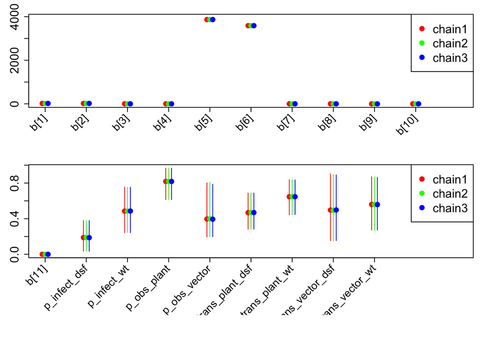

```r
chainsPlot(samples, nrows = 2, buffer.right = 1)
```

The effective sample size of the first chain is satisfactory, with a minimum of more than 1,000 effectively independent samples from all posterior dimensions, resulting from the 100,000 post burn-in samples.

```r
# Removed "eval = FALSE" from the chunk heading
(essTable <- round(cbind(
  length = apply(samples[[1]], 2, length),
  ESS    = effectiveSize(samples[[1]])
)))
```

```
##                    length   ESS
## b[1]                1e+05  2923
## b[2]                1e+05  4399
## b[3]                1e+05  3277
## b[4]                1e+05  4413
## b[5]                1e+05 75990
## b[6]                1e+05 83446
## b[7]                1e+05  5184
## b[8]                1e+05  8774
## b[9]                1e+05  3502
## b[10]               1e+05  4093
## b[11]               1e+05  5546
## p_infect_dsf        1e+05 12403
## p_infect_wt         1e+05 44427
## p_obs_plant         1e+05  6549
## p_obs_vector        1e+05  1170
## p_trans_plant_dsf   1e+05  6135
## p_trans_plant_wt    1e+05  6830
## p_trans_vector_dsf  1e+05  1261
## p_trans_vector_wt   1e+05  1921
```

```r
essTable <- data.frame(pars = row.names(essTable),
                       ess = essTable[,2])
essTable
```

```
##                                  pars   ess
## b[1]                             b[1]  2923
## b[2]                             b[2]  4399
## b[3]                             b[3]  3277
## b[4]                             b[4]  4413
## b[5]                             b[5] 75990
## b[6]                             b[6] 83446
## b[7]                             b[7]  5184
## b[8]                             b[8]  8774
## b[9]                             b[9]  3502
## b[10]                           b[10]  4093
## b[11]                           b[11]  5546
## p_infect_dsf             p_infect_dsf 12403
## p_infect_wt               p_infect_wt 44427
## p_obs_plant               p_obs_plant  6549
## p_obs_vector             p_obs_vector  1170
## p_trans_plant_dsf   p_trans_plant_dsf  6135
## p_trans_plant_wt     p_trans_plant_wt  6830
## p_trans_vector_dsf p_trans_vector_dsf  1261
## p_trans_vector_wt   p_trans_vector_wt  1921
```

[output not shown]

### Posterior Mean, Median, and 95% Credible Intervals

```r
res <- round(cbind(
    `cilower` = apply(samples[[1]], 2, function(x) quantile(x, 0.025)),
    `mean`         = apply(samples[[1]], 2, mean),
    `median`       = apply(samples[[1]], 2, median),
    `ciupper` = apply(samples[[1]], 2, function(x) quantile(x, 0.975))
), 5)

res
```

```
##                       cilower       mean     median    ciupper
## b[1]                 17.59045   17.59054   17.59054   17.59063
## b[2]                 17.93634   17.93641   17.93641   17.93647
## b[3]                 -0.18262   -0.18253   -0.18253   -0.18245
## b[4]                 -0.27145   -0.27138   -0.27138   -0.27130
## b[5]               3786.29498 3868.03778 3867.79135 3950.78722
## b[6]               3535.41034 3587.62375 3587.56532 3640.45217
## b[7]                  0.00036    0.00037    0.00037    0.00037
## b[8]                  0.00024    0.00024    0.00024    0.00024
## b[9]                 -5.63097   -2.73290   -2.53311   -0.97416
## b[10]                -3.46781   -1.49582   -1.38432   -0.18059
## b[11]                 0.00005    0.00019    0.00019    0.00038
## p_infect_dsf          0.03451    0.18808    0.18262    0.37868
## p_infect_wt           0.24257    0.48536    0.48003    0.75467
## p_obs_plant           0.61408    0.81813    0.82800    0.96717
## p_obs_vector          0.19552    0.39652    0.36550    0.80147
## p_trans_plant_dsf     0.28035    0.46756    0.46220    0.68710
## p_trans_plant_wt      0.44223    0.64613    0.64856    0.83686
## p_trans_vector_dsf    0.15282    0.49665    0.48670    0.90261
## p_trans_vector_wt     0.27227    0.55954    0.55733    0.87088
```

### Interpretations (updated v5)

##### Bacteria concentration in source plants (constant terms)

$\beta_1$, the constant term in the log() predictor for source plant xf concentration in genotype DSF plants, is essentially 17.591. Thus, the baseline xf concentration (at distance=0) in genotype DFS plants is $e^{\beta_1} \approx$ 44,000,000.

$\beta_2$, the constant term in the log() predictor for source plant xf concentration in genotype WT plants, is essentially 17.936, slightly *higher* than the genotype DSF constant term. Thus, the baseline xf concentration (at distance=0) in genotype WT plants is $e^{\beta_2} \approx$ 62,000,000.

These values of $\beta_1$ and $\beta_2$ imply that for the *same distance*, genotype WT plants will have more xf bacteria than genotype DSF plants. Specifically, higher in the WT plants by a factor of $e^{\beta_2-\beta_1} = e^{0.346}=$ 1.413.

##### Bacteria concentration in source plants (distance effect)

$\beta_3$, the coefficient of distance in the log() predictor for source plant xf concentration in genotype DSF plants, is essentially -0.183. For every additional unit of distance, the source plant xf concentration in DSF plants will decrease by a factor of $e^{\beta_3}=$ 0.833.

$\beta_4$, the coefficient of distance in the log() predictor for vector xf concentration in genotype WT plants, is essentially -0.271. This is significantly lower than that of genotype DSF plants, implying that the xf concentration decreases more rapidly (as a function of distance) in genotype WT plants, as compared to genotype DSF plants. Specicially, for every additional unit of distance, the source plant xf concentration in WT plants will decrease by a factor of $e^{\beta_4}=$ 0.762.

##### Bacteria presence or absense in source plant: true negative detections (new v5)

We allow some probability that there is 0 bacteria present at the source plant test site, regardless of distance. This probability is allowed to vary between DSF and WT source plant genotypes.

For DSF source plants, the probability of bacteria being present is estimated as 0.468, with 95% credible interval (0.28, 0.687).

For WT source plants, the probability of bacteria being present is estimated as 0.646, with 95% credible interval (0.442, 0.837).

This means that on average, there was a 47% chance of any bacteria being present at the test site in DSF plants, and a 65% chance of any bacteria being present at the test site in WT plants.

##### Bacteria transmission from source plants to vectors (vector concentration effect)

For DSF source plants, $\beta_5$ and $\beta_7$ determine the linear relationship for how xf is transmitted to vectors, as $\lambda_{vector} = \beta_5 + \beta_7 \cdot \lambda_{source\ plant}$. We are interested in the $\beta_7$ coefficient, which is approximately equal to 0.00037. This means that for DSF source plants, the vector xf concentration increases at a rate of 0.00037 times the source plant xf concentration.

For WT source plants, $\beta_6$ and $\beta_8$ determine the linear relationship for how xf is transmitted to vectors, as $\lambda_{vector} = \beta_6 + \beta_8 \cdot \lambda_{source\ plant}$. We are interested in the $\beta_8$ coefficient, which is approximately equal to 0.00024. This means that for WT source plants, the vector xf concentration increases at a rate of 0.00024 times the source plant xf concentration. This is a much *lower transmission rate* from (source plants to vectors) for WT plants, as compared to DSF plants.

```r
#### Example of relationship between lambda_vector and lambda_source_plant
# Given a population in source plant, what would be the predicted pop in vectors?

# Coefficients for DSF
beta5 <- res[row.names(res) == "b[5]", "median"]
beta7 <- res[row.names(res) == "b[7]", "median"]
# Coefficients for WT
beta6 <- res[row.names(res) == "b[6]", "median"]
beta8 <- res[row.names(res) == "b[8]", "median"]

# Given a value near the median xf_source_plant value:
median_xf_source <- data$xf_source_plant[data$xf_source_plant > 0] %>% median(., na.rm = TRUE)
example_xf_source <- round(median_xf_source, -6)
# The predicted population size in vectors would be:
pred_xf_vector_dsf <- beta5 + beta7*example_xf_source
pred_xf_vector_wt <- beta6 + beta8*example_xf_source

pred_xf_vector_dsf
```

```
## [1] 13857.79
```

```r
pred_xf_vector_wt
```

```
## [1] 10067.57
```

```r
# Proportion of vector WT to vector DSF Xf pops
pred_xf_vector_wt/pred_xf_vector_dsf
```

```
## [1] 0.7264913
```

##### Bacteria transmission from source plants to vectors: true negative detections (new v5)

We allow some probability that 0 bacteria is transmitted to the vector, regardless of the bacteria concentration in the source plant. This probability is allowed to vary between DSF and WT source plant genotypes.

For DSF source plants, the probability of bacteria being transmitted to the vector is estimated as 0.497, with 95% credible interval (0.153, 0.903).

For WT source plants, the probability of bacteria being transmitted to the vector is estimated as 0.56, with 95% credible interval (0.272, 0.871).

The probability of transmission of bacteria to the vectors was extremely similar between DSF and WT plants. Given there was bacteria present at the source plant test site, then there is a 50% chance of transmission to the vector from DSF source plants, and a 56% chance of transmission from WT source plants. These estimates were not statistically significantly different.

##### Probability of test plant infection (genotype effect)

$\beta_{9}$ gives the baseline probability of infection (on the logit scale) for genotype DSF plants. The 95% CI for $\beta_{9}$ is (-5.63, -0.97). Taking the inverse-logit transformation $\left( \tfrac{1}{1+e^{-x}} \right)$, this gives a 95% CI for the baseline probability of infection for DSF source plants as (0, 0.27). This does not take xf concentration in the vector into account.

$\beta_{10}$ gives the baseline probability of infection (on the logit scale) for genotype WT plants. The 95% CI for $\beta_{10}$ is (-3.47, -0.18). Taking the inverse-logit transformation $\left( \tfrac{1}{1+e^{-x}} \right)$, this gives a 95% CI for the baseline probability of infection for WT source plants as (0.03, 0.45). This does not take xf concentration in the vector into account.

##### Probability of test plant infection (vector xf effect) (significant change v5)

$\beta_{11}$ is the coefficient for vector xf level in the logit() predictor for test plant infection. That is, this (on the logit scale) determines how vector xf concentration affects the probability of test plant infection.

This means that increased vector xf concentration does have a significant positive effect on the probability of test plant infection. It’s difficult to exactly quantify how much the probability of infection will increase as the vector xf concentration increases, since this coefficient is on the logit scale.

However, given that the observed (non-zero) vector xf concentrations are roughly between 1,000 and 60,000, this implies an increase (on the logit scale) of between (1000)(0.00019) = 0.19 and (60000)(0.00019) = 11.4. An increase of 0.19 (on the logit scale) implies a noteworthy, although not massive increase in the probability of infection; the increase of 11.4 (on the logit scale) is large enough to ensure a probability of infection essentially equal to 1.

##### Bacteria detection (source plants, vectors)

$p_{obs.\ source\ plant}$, the probability of xf detection in source plants, is bounded by the 95% CI (0.61, 0.97), with median 0.828. This means the test used has about an 83% chance of detecting any xf bacteria in source plants.

$p_{obs.\ vector}$, the probability of xf detection in vectors, is bounded by the 95% CI (0.2, 0.8) , with median 0.366. This means the test used has about a 37% chance of detecting any xf bacteria in vectors.

##### Predictive distributions for test plant infection

The predictive nodes give the best idea of the probability of infection, from either DSF or WT source plants, predicted at distance = 0. These estimates take all model parameters and biological processes into account.

- Probability of infection for genotype DSF (at distance = 0) is in the 95% CI: (0.03, 0.38), with median = 0.18.
- Probability of infection for genotype WT (at distance = 0) is in the 95% CI: (0.24, 0.75), with median = 0.48.

Next, we look at the probabilities of infection from *all test plants*, separated by genotype. These do not assume any particular distance (*e.g.*, distance = 0). Instead, these quite literally represent *all* distances in the input data set.

```r
#### Plotting model results -- summaries of posterior probabilities for coefficient and probability estimates

dsf_ind <- intersect(which(constants$genotype_dsf == 1), constants$obs_ind_infected)
wt_ind  <- intersect(which(constants$genotype_wt  == 1), constants$obs_ind_infected)
pinfect_dsf_nodes <- paste0('p_infect[', dsf_ind, ']')
pinfect_wt_nodes  <- paste0('p_infect[', wt_ind,  ']')
pinfect_dsf <- as.numeric(samples2[, pinfect_dsf_nodes])
pinfect_wt  <- as.numeric(samples2[, pinfect_wt_nodes])
dsf_res <- c(quantile(pinfect_dsf,0.025), mean(pinfect_dsf), median(pinfect_dsf), quantile(pinfect_dsf,0.975))
wt_res <-  c(quantile(pinfect_wt, 0.025), mean(pinfect_wt ), median(pinfect_wt ), quantile(pinfect_wt, 0.975))
infection_results <- rbind(dsf_res, wt_res)
rownames(infection_results) <- c('p_infect_dsf', 'p_infect_wt')
colnames(infection_results) <- c("cilower", "mean", "median", "ciupper")
round(infection_results, 2)
```

```
##              cilower mean median ciupper
## p_infect_dsf    0.01 0.27   0.15    0.93
## p_infect_wt     0.05 0.46   0.36    0.99
```

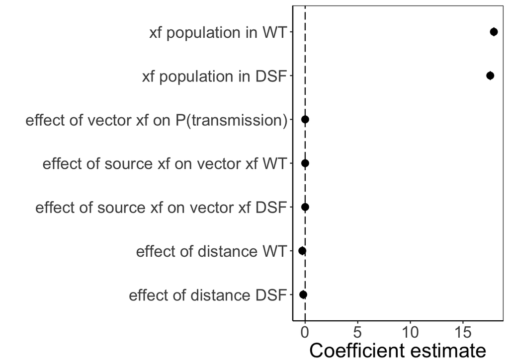

```r
#### Plot of parameter estimates (medians) and 95% CI
library(ggplot2); library(cowplot)
# Add full estimate of p_infect to the results table
row.names(infection_results) <- c("p_infect_dsf_full", "p_infect_wt_full")
plotres <- rbind(res, infection_results) %>% as.data.frame()
names(plotres) <- c("cilower", "mean", "median", "ciupper")
plotres$pars <- row.names(plotres)

# Variable names for figure
plotres$covarNames <- c("xf population in DSF", "xf population in WT", # b1, b2
                    "effect of distance DSF", "effect of distance WT", # b3, b4
                    "intercept source xf on vector xf DSF", "intercept source xf on vector xf WT", # b5, b6
                    "effect of source xf on vector xf DSF", "effect of source xf on vector xf WT", # b7, b8
                    "baseline P(transmission) DSF", "baseline P(transmission) WT", # b9, 910
                    "effect of vector xf on P(transmission)", # b11
                    "P(transmission) from inoculation point DSF", "P(transmission) from inoculation point WT",
                    "P(detection) source plant", "P(detection) vector",
                    "P(colonization) source plant DSF", "P(colonization) source plant WT",
                    "P(colonization) vector DSF", "P(colonization) vector WT",
                    "P(transmission) all distances DSF", "P(transmission) all distances WT")

#### Plotting results
# Plot coefficient estimates and probabilities separately -- on slightly different scales
# Coefficient estimates
plotres1 <- plotres %>% dplyr::filter(pars == "b[1]" | pars == "b[2]" | pars == "b[3]" | pars == "b[4]" |
                                        pars == "b[7]" | pars == "b[8]" | pars == "b[11]")

coef_plot <- ggplot(plotres1, aes(y = covarNames, x = median)) +
  geom_errorbarh(aes(xmin = cilower, xmax = ciupper), colour = "black", height = 0.2) +
  geom_point(size = 3) +
  geom_vline(linetype = "longdash", xintercept = 0) +
  xlab("Coefficient estimate") + ylab("") +
  theme_bw() +
  theme(axis.line = element_line(colour = "black"),
        text = element_text(size = 20),
        panel.grid.major = element_blank(),
        panel.grid.minor = element_blank(),
        panel.border = element_rect(colour = "black"),
        panel.background = element_blank())
coef_plot
```

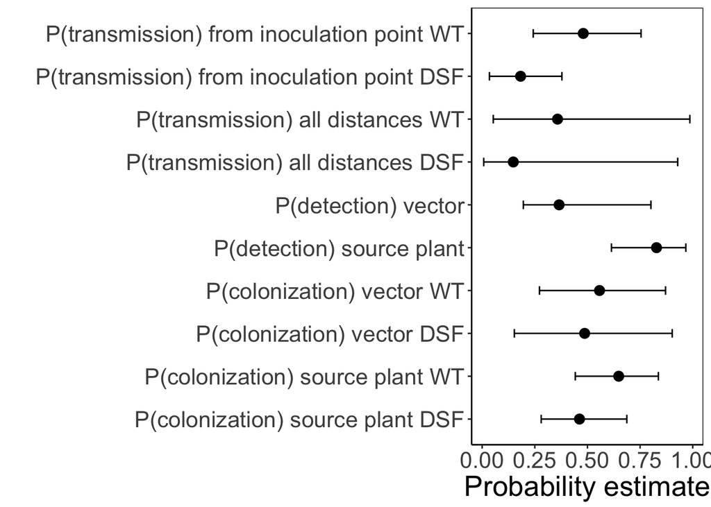

```r
ggsave(filename = "results/coefficient_plot.tiff",
       plot = coef_plot,
       width = 10, height = 7, units = "in")

## Probability estimates
# Plot only probabilities because they are a different scale from the coefficients
plotres2 <- plotres %>% dplyr::filter(grepl("p_", pars))

coef_plot2 <- ggplot(plotres2, aes(y = covarNames, x = median)) +
  geom_errorbarh(aes(xmin = cilower, xmax = ciupper), colour = "black", height = 0.2) +
  geom_point(size = 3) +
  #geom_vline(linetype = "longdash", xintercept = 0) +
  xlab("Probability estimate") + ylab("") +
  xlim(c(0,1)) +
  theme_bw() +
  theme(axis.line = element_line(colour = "black"),
        text = element_text(size = 20),
        panel.grid.major = element_blank(),
        panel.grid.minor = element_blank(),
        panel.border = element_rect(colour = "black"),
        panel.background = element_blank())
coef_plot2
```

```r
ggsave(filename = "results/probability_estimate_plot.tiff",
       plot = coef_plot2,
       width = 10, height = 7, units = "in")


#### Make a results table for manuscript
# Includes Gelman-Rubin diagnostic and Effective Sample Size diagnostic
# And includes CI and medians

resultsTable <- plotres %>%
  left_join(., grTable, by = "pars") %>% # Join GR diagnostic table
  left_join(., essTable, by = "pars") %>% # Join ESS table
  mutate(., summary = paste(signif(median,3), " [", signif(cilower,3), ", ", signif(ciupper,3), "]", sep="")) %>% # Combine median and CI
  dplyr::select(covarNames, pars, gr, ess, summary) # select and order only columns I want in the table
resultsTable
```

```
##                                    covarNames               pars       gr
## 1                        xf population in DSF               b[1]    1 (1)
## 2                         xf population in WT               b[2] 1 (1.01)
## 3                      effect of distance DSF               b[3]    1 (1)
## 4                       effect of distance WT               b[4]    1 (1)
## 5        intercept source xf on vector xf DSF               b[5]    1 (1)
## 6         intercept source xf on vector xf WT               b[6]    1 (1)
## 7        effect of source xf on vector xf DSF               b[7]    1 (1)
## 8         effect of source xf on vector xf WT               b[8]    1 (1)
## 9                baseline P(transmission) DSF               b[9]    1 (1)
## 10                baseline P(transmission) WT              b[10]    1 (1)
## 11     effect of vector xf on P(transmission)              b[11]    1 (1)
## 12 P(transmission) from inoculation point DSF       p_infect_dsf    1 (1)
## 13  P(transmission) from inoculation point WT        p_infect_wt    1 (1)
## 14                  P(detection) source plant        p_obs_plant    1 (1)
```

[output cut: 29 more lines]

```r
write.csv(resultsTable, file = "results/nimble_model_results_table.csv", row.names = FALSE)
```

We see that:

- Probabilities of infection for genotype DSF plants are in the 95% CI: (0.01, 0.93), with median = 0.15.
- Probabilities of infection for genotype WT plants are in the 95% CI: (0.05, 0.99), with median = 0.36.

This is not so surprising. It says that for each genotype, when we consider **all** plant, vector, and distance combinations, there’s huge variation (nearly spanning the interval [0, 1]) in the probability of test plant infection.

### Hierarchical Plots (updated v5)

Predicted probability of infection versus observed xf concentration in vectors (log base 10), separated by genotype. We include best-fit regression lines.

This plot has been updated since adding the new probabilistic models for zero xf transmissions, in the source plant and the vectors. The plot below shows how the probability of infection varies as a function of xf concentration in the vectors, for each plant genotype.

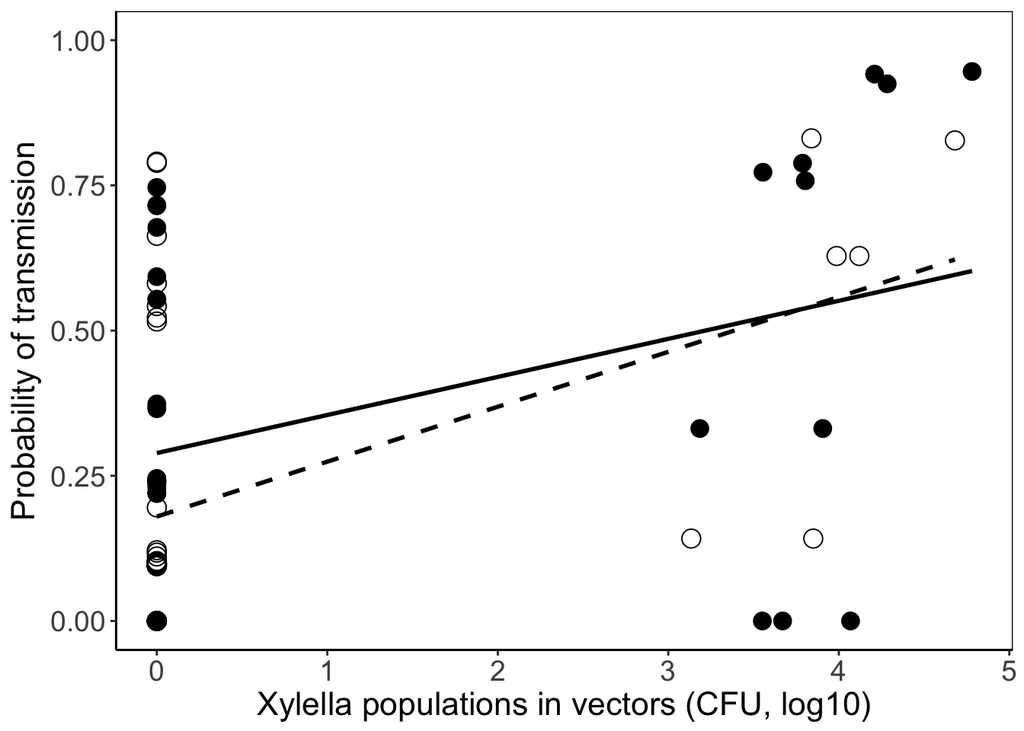

```r
## indices of DSF and WT cases for which xf_vector was observed
dsf_ind <- intersect(which(constants$genotype_dsf == 1), constants$obs_ind_vector)
wt_ind  <- intersect(which(constants$genotype_wt  == 1), constants$obs_ind_vector)
## get xf_vector values for each genotype, and take log base 10
xf_vector_dsf_log10 <- log10(data$xf_vector[dsf_ind])
xf_vector_wt_log10  <- log10(data$xf_vector[wt_ind])
## change -infinity to 0
xf_vector_dsf_log10[xf_vector_dsf_log10 < 0] <- 0
xf_vector_wt_log10 [xf_vector_wt_log10  < 0] <- 0
## get samples of p_infect for each genotype, and take the median
p_infect_dsf_nodes <- paste0('p_infect[', dsf_ind, ']')
p_infect_wt_nodes  <- paste0('p_infect[', wt_ind,  ']')
p_infect_dsf <- apply(samples2[, p_infect_dsf_nodes], 2, median, na.rm = TRUE)
p_infect_wt  <- apply(samples2[, p_infect_wt_nodes],  2, median, na.rm = TRUE)


#### Create data set of predicted results and plot in ggplot
# Make a WT data.frame and a DSF data.frame, then combine them
dsfdf <- data.frame(xf_vector_log10 = xf_vector_dsf_log10,
                    p_infect = p_infect_dsf,
                    genotype = "DSF")
wtdf <- data.frame(xf_vector_log10 = xf_vector_wt_log10,
                   p_infect = p_infect_wt,
                   genotype = "WT")
plotdf <- rbind(dsfdf, wtdf)

#### Plotting probability of transmission vs vector xf populations
vectorTransPlot <- ggplot(data = plotdf) +
  geom_point(data = plotdf[plotdf$genotype == "WT",], aes(y = p_infect, x = xf_vector_log10), size = 4, pch = 16) +
  geom_point(data = plotdf[plotdf$genotype == "DSF",], aes(y = p_infect, x = xf_vector_log10), size = 4, pch = 1) +
  stat_smooth(data = plotdf[plotdf$genotype == "WT",], aes(y = p_infect, x = xf_vector_log10), method = "lm", se = FALSE, col = "black", lty = 1) +
  stat_smooth(data = plotdf[plotdf$genotype == "DSF",], aes(y = p_infect, x = xf_vector_log10), method = "lm", se = FALSE, col = "black", lty = 2) +
  xlab("Xylella populations in vectors (CFU, log10)") + ylab("Probability of transmission") + ylim(0,1) +
  theme_bw() +
  theme(axis.line = element_line(colour = "black"),
        axis.text = element_text(size=14),
        axis.title = element_text(size=16),
        panel.grid.major = element_blank(),
        panel.grid.minor = element_blank(),
        panel.border = element_rect(colour = "black"),
        panel.background = element_blank())
vectorTransPlot
```

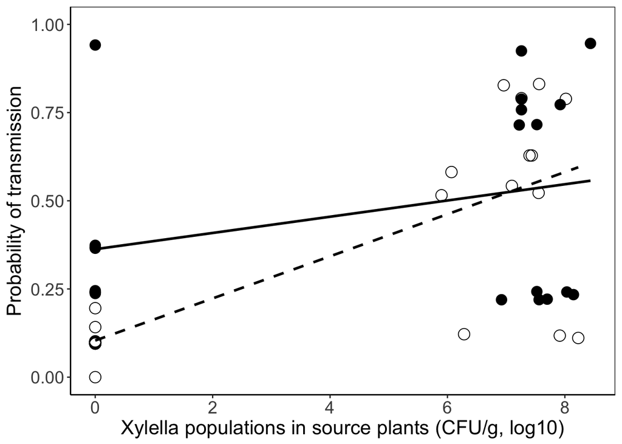

```r
ggsave(filename = "results/transmission_vectorxf_plot.tiff",
       plot = vectorTransPlot,
       width = 7, height = 7, units = "in")



#### Plotting probability of transmission vs source plant populations
## Plot of transmission vs. xf in source plant, using original xf_source data
plotdf$xf_source_log10 <- log10(c(data$xf_source_plant[dsf_ind], data$xf_source_plant[wt_ind]))
## change -infinity to 0
plotdf$xf_source_log10[plotdf$xf_source_log10 < 0] <- 0


## p_infect vs. xf_source in ggplot
sourceTransPlot <- ggplot(data = plotdf) +
  geom_point(data = plotdf[plotdf$genotype == "WT",], aes(y = p_infect, x = xf_source_log10), size = 4, pch = 16) +
  geom_point(data = plotdf[plotdf$genotype == "DSF",], aes(y = p_infect, x = xf_source_log10), size = 4, pch = 1) +
  stat_smooth(data = plotdf[plotdf$genotype == "WT",], aes(y = p_infect, x = xf_source_log10), method = "lm", se = FALSE, col = "black", lty = 1) +
  stat_smooth(data = plotdf[plotdf$genotype == "DSF",], aes(y = p_infect, x = xf_source_log10), method = "lm", se = FALSE, col = "black", lty = 2) +
  xlab("Xylella populations in source plants (CFU/g, log10)") + ylab("Probability of transmission") + ylim(0,1) +
  theme_bw() +
  theme(axis.line = element_line(colour = "black"),
        axis.text = element_text(size=14),
        axis.title = element_text(size=16),
        panel.grid.major = element_blank(),
        panel.grid.minor = element_blank(),
        panel.border = element_rect(colour = "black"),
        panel.background = element_blank())
sourceTransPlot
```

```r
ggsave(filename = "results/transmission_sourcexf_plot.tiff",
       plot = sourceTransPlot,
       width = 7, height = 7, units = "in")
```

### Posterior Density Plots (updated v5)

##### Predictive distributions for test plant infection (significantly updated v5)

Below are the posterior predictive distributions for test plant infection, for genotype DSF and WT plants, predicted at distance = 0.

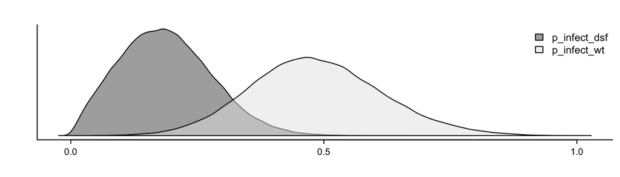

```r
samplesPlot(samples[[1]], c('p_infect_dsf','p_infect_wt'), width = 4, height = 2, traceplot = FALSE)
```

The much larger mass near to probability of infection = 0 for the DSF genotype is explained by the results we’ve seen above. For DSF plants there was only a 47% chance of any bacteria being present at the source plant test site (versus 65% chance for WT plants; much more likely to have bacteria). And more minor, but still pushing the results in the same direction, the probability of bacteria transmission to the vectors was 50% for DSF source plants (versus a higher 56% for WT plants). Both of these results (from the new probabilistic transmission models) drive the results below, where there’s a large mode around probability of infection = 0 for DSF plants, and a similar but much smaller mode for WT source plants.

```r
#### Plot posterior probabilities for P(transmission)
set.seed(0)
pinfect_df <- data.frame(p_infect_dsf = sample(pinfect_dsf,length(pinfect_wt)),
                         p_infect_wt  = pinfect_wt)
samplesPlot(pinfect_df, c('p_infect_wt', 'p_infect_dsf'), width = 4, height = 2, traceplot = FALSE, legend = FALSE,
              file = "results/posterior_density_ptransmission_plot.pdf")
```

##### Posterior densities of transmission probabilities (new v5)

First, compare the posterior distributions of presense of xf bacteria at source plant test sites, for DSF and WT source plants.

We see a reasonable difference in these probabilities, namely that WT source plants are more likely to have bacteria present at the test site.

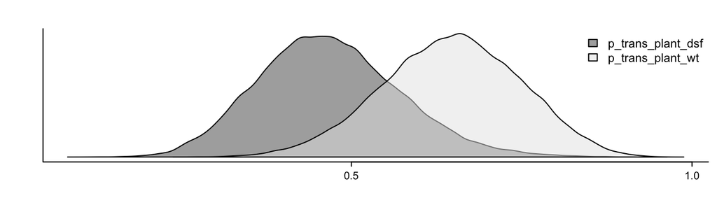

```r
samplesPlot(samples[[1]], c('p_trans_plant_dsf', 'p_trans_plant_wt'), width = 4, height = 2, traceplot = FALSE)
```

Next, compare the posterior distributions of transfer of xf bacteria from the source plant to the vectors, for DSF and WT source plants.

We see essentially no difference here between DSF at WT source plants. If bacteria are present at the test site, then vectors are equally likely to acquire the bacteria from either at DSF or a WT source plant.

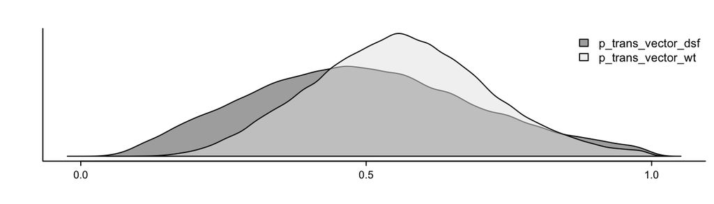

```r
samplesPlot(samples[[1]], c('p_trans_vector_dsf', 'p_trans_vector_wt'), width = 4, height = 2, traceplot = FALSE)
```

##### New Predictive plots

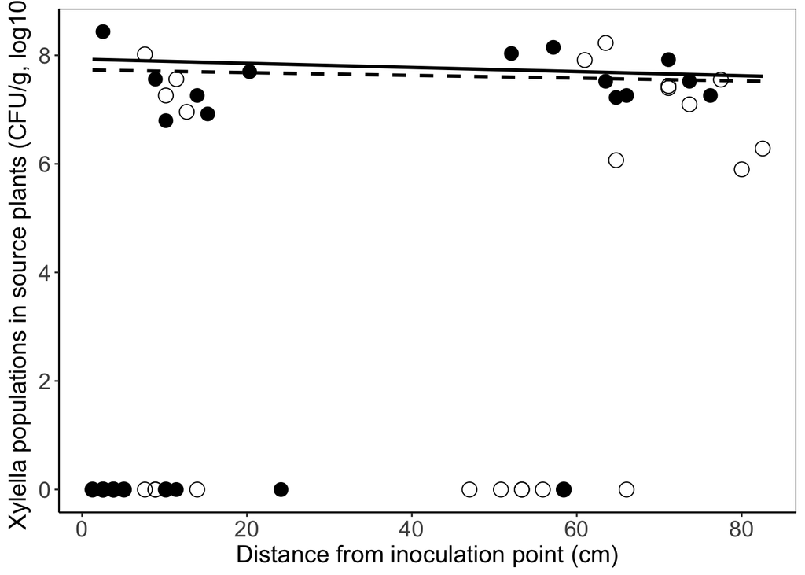

```r
library(dplyr)

#### Figures from predictive nodes
## Includes xf_source vs. distance and xf_vector vs xf_source

## Set up new data.frame for plotting
dsf_ind <- constants$genotype_dsf == 1
wt_ind  <- constants$genotype_wt  == 1

# Predicted values for xf_source and xf_vector, from the lambdas in the model
pred_xf_source_plant <- samples2[,grep("^pred_xf_source_plant", colnames(samples2))]
pred_xf_vector       <- samples2[,grep("^pred_xf_vector",       colnames(samples2))]

## This data.frame includes all data needed for both plots
pred_df <- data.frame(
    genotype = ifelse(constants$genotype_dsf, 'DSF', 'WT'),
    distance = dsf$dsfData$raw_distance,
    xf_source_plant = data$xf_source_plant,
    xf_vector = data$xf_vector,
    xf_plant_med = unname(apply(pred_xf_source_plant, 2, median)),
    xf_vector_med = unname(apply(pred_xf_vector, 2, median)),
    xf_source_log10 = log10(data$xf_source_plant),
    xf_vector_log10 = log10(data$xf_vector),
    xf_plant_med_log10  = log10(unname(apply(pred_xf_source_plant, 2, median))),
    xf_vector_med_log10 = log10(unname(apply(pred_xf_vector, 2, median)))
)

# Set -Inf to 0
for(i in grep("_log10", names(pred_df))){
  pred_df[,i] <- ifelse(pred_df[,i] < 0, 0, pred_df[,i])
}

## Order data.frame according to distance and then split by genotype
pred_df %>% arrange(distance) -> pred_df
pred_df %>% filter(genotype == 'DSF') -> pred_df_dsf
pred_df %>% filter(genotype == 'WT')  -> pred_df_wt


#### Plot of xf_source_plant vs. distance
# Plot only data with xf_source_plant > 0
pred_nz <- pred_df %>% filter(xf_source_log10 > 0)

distanceSourcePlot <- ggplot(data = pred_df) +
  geom_point(data = pred_df[pred_df$genotype == "WT",],
             aes(y = xf_source_log10, x = distance), size = 4, pch = 16) +
  geom_point(data = pred_df[pred_df$genotype == "DSF",],
             aes(y = xf_source_log10, x = distance), size = 4, pch = 1) +
  stat_smooth(data = pred_df[pred_df$genotype == "WT",],
              aes(y = xf_plant_med_log10, x = distance), method = "lm", se = FALSE, col = "black", lty = 1) +
  stat_smooth(data = pred_df[pred_df$genotype == "DSF",],
              aes(y = xf_plant_med_log10, x = distance), method = "lm", se = FALSE, col = "black", lty = 2) +
  ylab("Xylella populations in source plants (CFU/g, log10)") + xlab("Distance from inoculation point (cm)") + #ylim(0,1) +
  theme_bw() +
  theme(axis.line = element_line(colour = "black"),
        axis.text = element_text(size=14),
        axis.title = element_text(size=15),
        panel.grid.major = element_blank(),
        panel.grid.minor = element_blank(),
        panel.border = element_rect(colour = "black"),
        panel.background = element_blank())
distanceSourcePlot
```

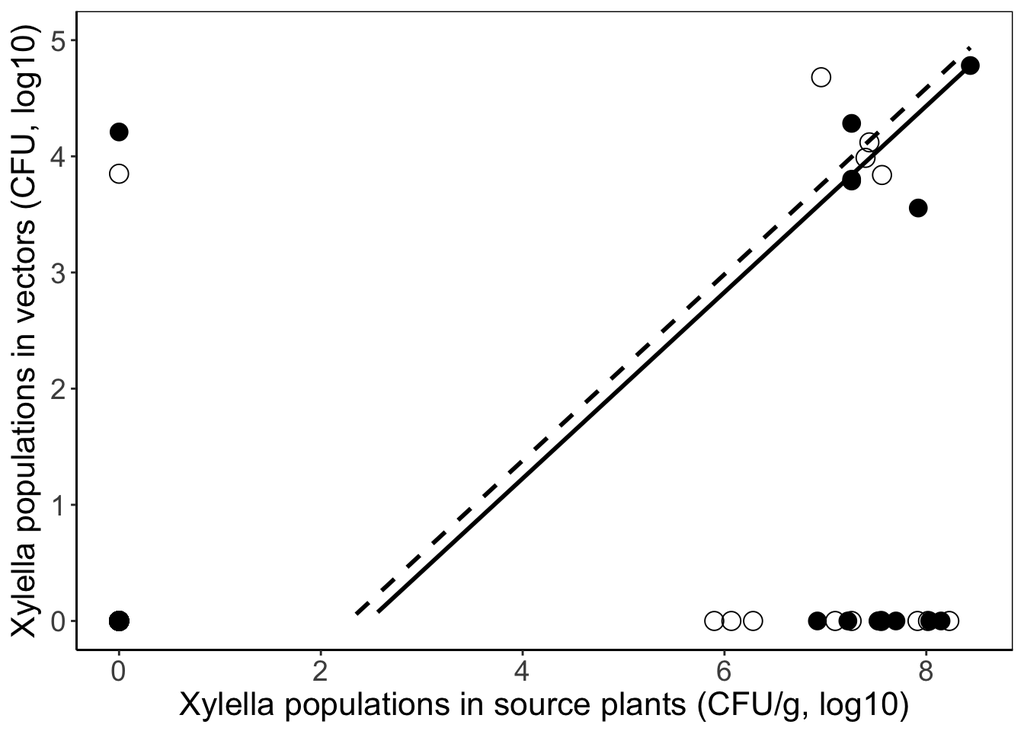

```r
ggsave(filename = "results/sourcexf_distance_plot.tiff",
       plot = distanceSourcePlot,
       width = 7, height = 7, units = "in")
#### Plot of xf_vector vs xf_source_plant
pred_nz2 <- pred_nz %>% dplyr::filter(xf_vector_log10 > 0)

sourceVectorPlot <- ggplot(data = pred_df) +
  geom_point(data = pred_df[pred_df$genotype == "WT",],
             aes(y = xf_vector_log10, x = xf_source_log10), size = 4, pch = 16) +
  geom_point(data = pred_df[pred_df$genotype == "DSF",],
             aes(y = xf_vector_log10, x = xf_source_log10), size = 4, pch = 1) +
  stat_smooth(data = pred_df[pred_df$genotype == "WT",],
              aes(y = xf_vector_med_log10, x = xf_plant_med_log10), method = "lm", se = FALSE, fullrange = TRUE, col = "black", lty = 1) +
  stat_smooth(data = pred_df[pred_df$genotype == "DSF",],
              aes(y = xf_vector_med_log10, x = xf_plant_med_log10), method = "lm", se = FALSE, fullrange = TRUE, col = "black", lty = 2) +
  xlab("Xylella populations in source plants (CFU/g, log10)") + ylab("Xylella populations in vectors (CFU, log10)") + ylim(c(0,5)) +
  theme_bw() +
  theme(axis.line = element_line(colour = "black"),
        axis.text = element_text(size=14),
        axis.title = element_text(size=16),
        panel.grid.major = element_blank(),
        panel.grid.minor = element_blank(),
        panel.border = element_rect(colour = "black"),
        panel.background = element_blank())
sourceVectorPlot
```

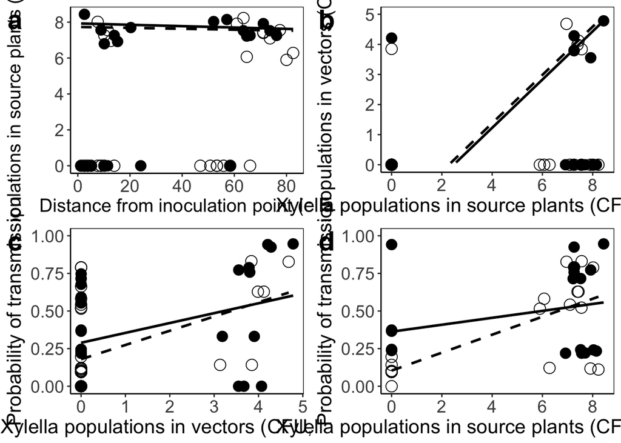

```r
ggsave(filename = "results/sourcexf_distance_plot.tiff",
       plot = distanceSourcePlot,
       width = 7, height = 7, units = "in")
#### Combining plots into Figure 2 for ms
library(cowplot)
fig2 <- plot_grid(distanceSourcePlot, sourceVectorPlot, vectorTransPlot, sourceTransPlot,
                  align = "v", ncol = 2, nrow = 2, labels = "auto", label_size = 22)
fig2
```

```r
ggsave(filename = "results/figure2.tiff",
       plot = fig2,
       width = 12, height = 12, units = "in", dpi = 600)
```

##### Posterior densities of all model parameters

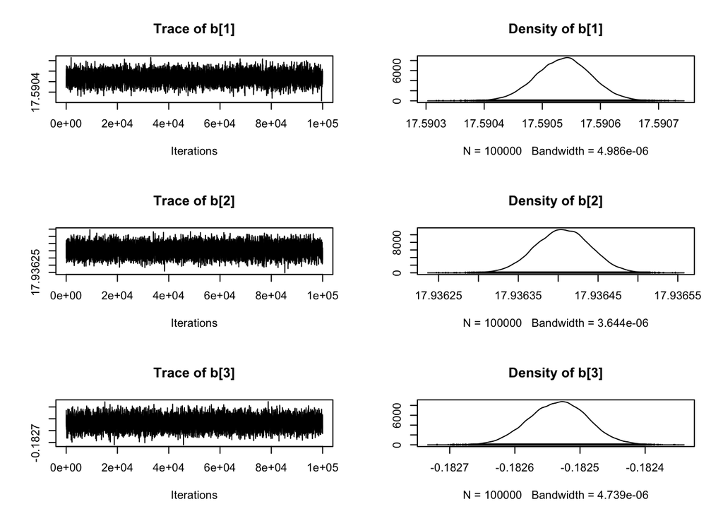

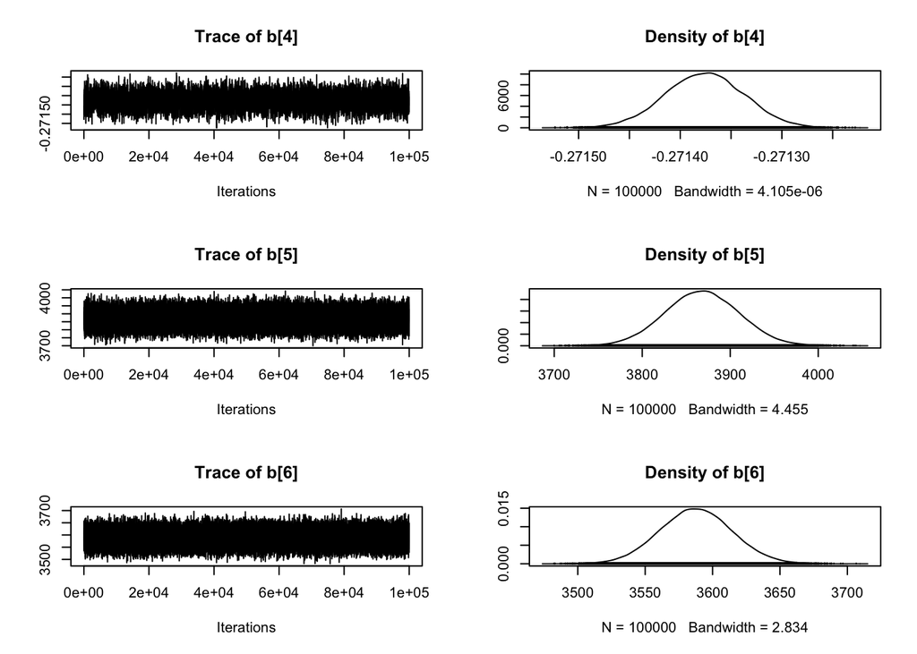

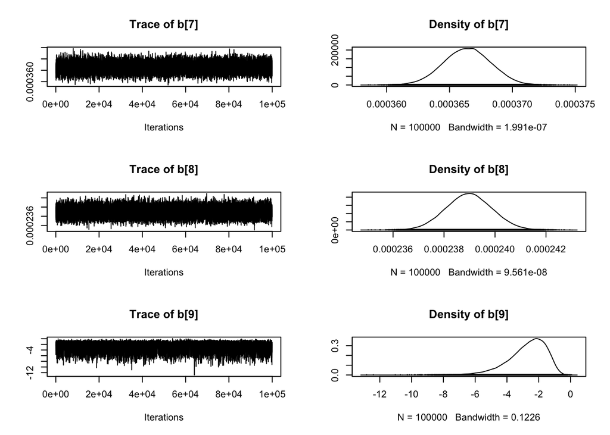

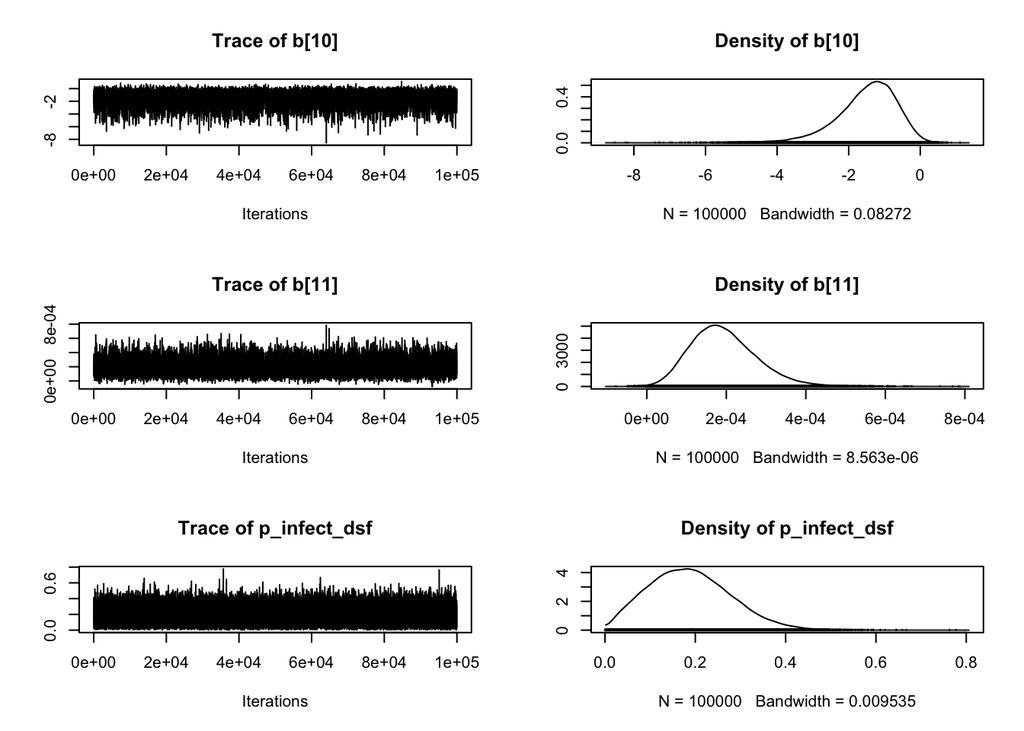

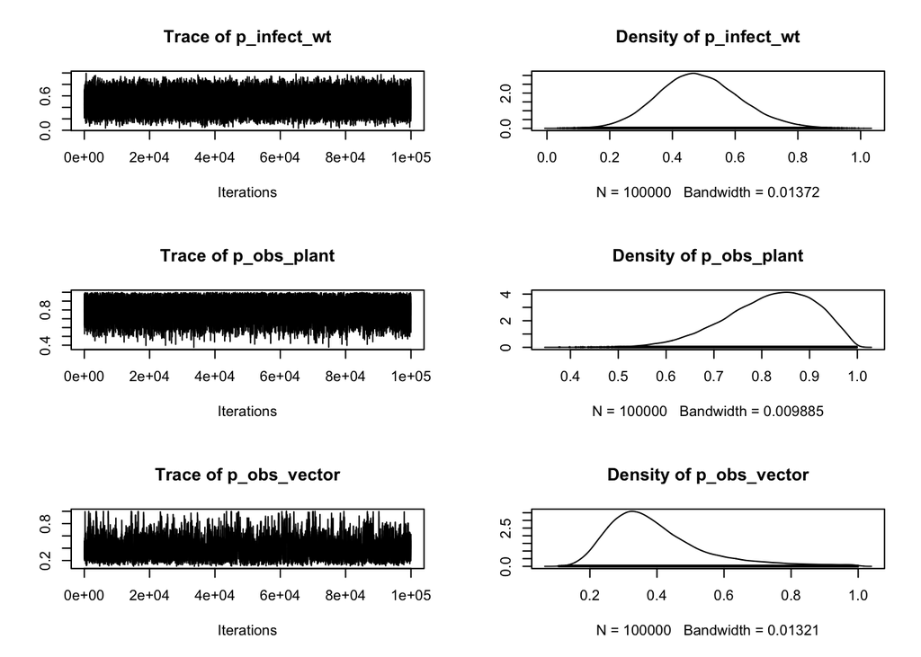

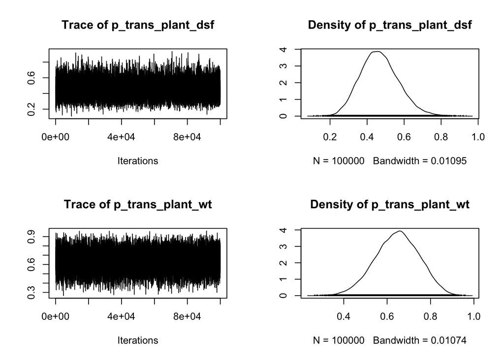

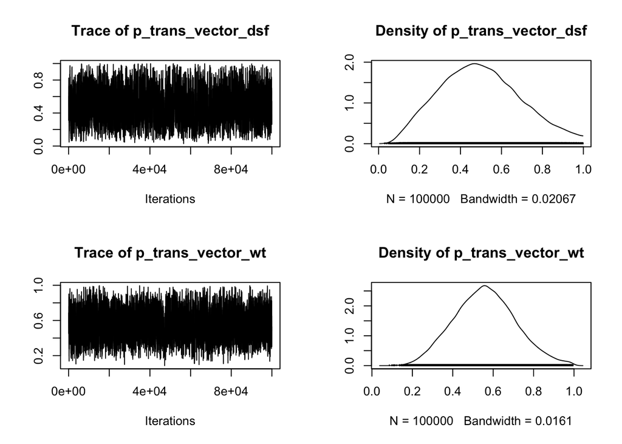

```r
plot(coda::as.mcmc(samples[[1]]), ask = FALSE)
```